# Assignment 4 - Forecasting Models

2026-10-05

## Load Packages

```r
library(forecast)
library(ggplot2)
```

## Import Data

```r
electronics <- read.csv("Retail Sales - Electronics Stores.csv")
head(electronics)
```

```
##   observation_date MRTSSM443142USN
## 1       2016-01-01            5926
## 2       2016-02-01            6043
## 3       2016-03-01            6065
## 4       2016-04-01            5318
## 5       2016-05-01            5657
## 6       2016-06-01            5736
```

## Create Time Series

```r
electronics_ts <- ts(electronics$MRTSSM443142USN, start = c(2016, 1), frequency = 12)
electronics_ts
```

```
##       Jan  Feb  Mar  Apr  May  Jun  Jul  Aug  Sep  Oct  Nov  Dec
## 2016 5926 6043 6065 5318 5657 5736 5828 6257 5814 5581 7452 9664
## 2017 5657 5359 5925 5254 5629 5703 5598 5996 5822 5717 8062 9817
## 2018 5943 5633 6047 5417 5792 5914 5811 6235 5842 5831 7940 9499
## 2019 5910 5336 5795 5116 5576 5515 5569 5956 5666 5572 7591 9256
## 2020 5650 5244 4326 1783 2346 3727 4544 4809 4536 4876 6271 7359
## 2021 5073 4527 5799 5396 5640 5891 5984 5951 5659 5998 6966 8526
## 2022 5249 4928 5889 5529 5452 5315 5541 5738 5694 5464 6424 7878
## 2023 5701 5118 5537 4923 5356 5388 5338 5616 5629 5507 6784 8120
## 2024 5669 5447 5332 5131 5656 5317 5577 5639 5148 5452 6992 8583
## 2025 5473 5067 5437 5051 5631 5310 5685 5787 5546 5589 7047 8799
```

## Plot the Time Series

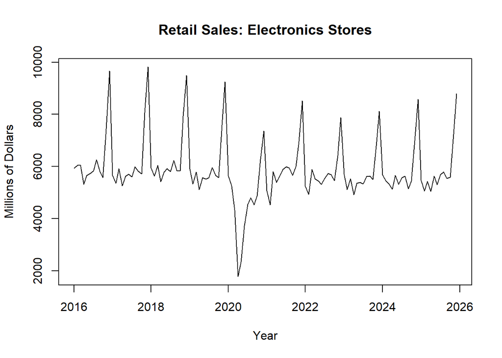

```r
plot(electronics_ts, main = "Retail Sales: Electronics Stores", xlab = "Year", ylab = "Millions of Dollars")
```

## Mean Forecast

```r
mean_forecast <- meanf(electronics_ts, h = 12)
mean_forecast
```

```
##          Point Forecast    Lo 80    Hi 80    Lo 95    Hi 95
## Jan 2026       5866.717 4337.168 7396.266 3516.561 8216.872
## Feb 2026       5866.717 4337.168 7396.266 3516.561 8216.872
## Mar 2026       5866.717 4337.168 7396.266 3516.561 8216.872
## Apr 2026       5866.717 4337.168 7396.266 3516.561 8216.872
## May 2026       5866.717 4337.168 7396.266 3516.561 8216.872
## Jun 2026       5866.717 4337.168 7396.266 3516.561 8216.872
## Jul 2026       5866.717 4337.168 7396.266 3516.561 8216.872
## Aug 2026       5866.717 4337.168 7396.266 3516.561 8216.872
## Sep 2026       5866.717 4337.168 7396.266 3516.561 8216.872
## Oct 2026       5866.717 4337.168 7396.266 3516.561 8216.872
## Nov 2026       5866.717 4337.168 7396.266 3516.561 8216.872
## Dec 2026       5866.717 4337.168 7396.266 3516.561 8216.872
```

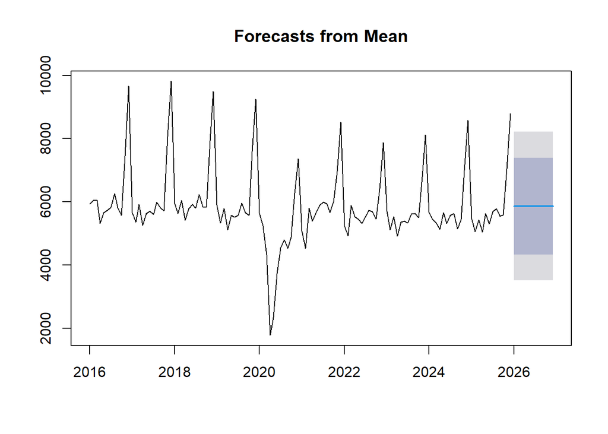

```r
plot(mean_forecast)
```

The mean forecasting method predicts future values using the average of all historical observations. The model forecasts monthly electronics store sales of approximately $5,866.7 million for each month of 2026. The forecast is constant because the mean method does not account for changes in trend or seasonal patterns. This may be a limitation for this dataset because the historical sales data show noticeable seasonal spikes near the end of each year.

## Naive Forecast

```r
naive_forecast <- naive(electronics_ts, h = 12)
naive_forecast
```

```
##          Point Forecast    Lo 80    Hi 80    Lo 95    Hi 95
## Jan 2026           8799 7269.062 10328.94 6459.161 11138.84
## Feb 2026           8799 6635.340 10962.66 5489.968 12108.03
## Mar 2026           8799 6149.069 11448.93 4746.280 12851.72
## Apr 2026           8799 5739.123 11858.88 4119.322 13478.68
## May 2026           8799 5377.954 12220.05 3566.961 14031.04
## Jun 2026           8799 5051.431 12546.57 3067.588 14530.41
## Jul 2026           8799 4751.163 12846.84 2608.368 14989.63
## Aug 2026           8799 4471.681 13126.32 2180.936 15417.06
## Sep 2026           8799 4209.185 13388.82 1779.483 15818.52
## Oct 2026           8799 3960.910 13637.09 1399.779 16198.22
## Nov 2026           8799 3724.768 13873.23 1038.632 16559.37
## Dec 2026           8799 3499.138 14098.86  693.560 16904.44
```

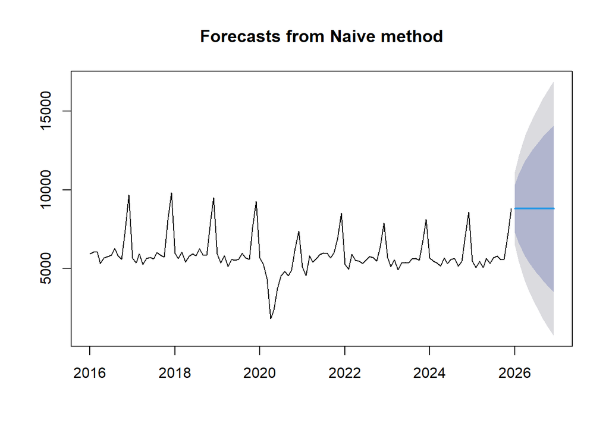

```r
plot(naive_forecast)
```

The naive forecasting method uses the most recent observation as the forecast for all future periods. Since electronics store sales were $8,799 million in December 2025, the model forecasts $8,799 million for each month of 2026. The prediction intervals become wider further into the forecast period, indicating greater uncertainty. This method may not fit the data well because December has historically been a high-sales month, so using December sales to predict every month does not account for the seasonal pattern in the data.

## Random Walk Forecast

```r
rw_forecast <- rwf(electronics_ts, h = 12)
rw_forecast
```

```
##          Point Forecast    Lo 80    Hi 80    Lo 95    Hi 95
## Jan 2026           8799 7269.062 10328.94 6459.161 11138.84
## Feb 2026           8799 6635.340 10962.66 5489.968 12108.03
## Mar 2026           8799 6149.069 11448.93 4746.280 12851.72
## Apr 2026           8799 5739.123 11858.88 4119.322 13478.68
## May 2026           8799 5377.954 12220.05 3566.961 14031.04
## Jun 2026           8799 5051.431 12546.57 3067.588 14530.41
## Jul 2026           8799 4751.163 12846.84 2608.368 14989.63
## Aug 2026           8799 4471.681 13126.32 2180.936 15417.06
## Sep 2026           8799 4209.185 13388.82 1779.483 15818.52
## Oct 2026           8799 3960.910 13637.09 1399.779 16198.22
## Nov 2026           8799 3724.768 13873.23 1038.632 16559.37
## Dec 2026           8799 3499.138 14098.86  693.560 16904.44
```

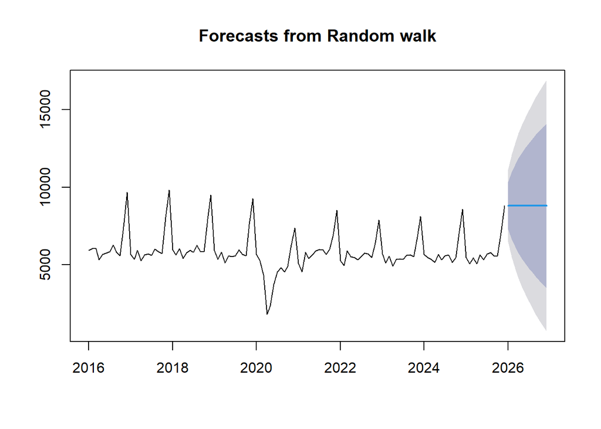

```r
plot(rw_forecast)
```

## Random Walk with Drift

```r
drift_forecast <- rwf(electronics_ts, h = 12, drift = TRUE)
drift_forecast
```

```
##          Point Forecast    Lo 80    Hi 80     Lo 95    Hi 95
## Jan 2026       8823.143 7280.609 10365.68 6464.0406 11182.25
## Feb 2026       8847.286 6656.743 11037.83 5497.1390 12197.43
## Mar 2026       8871.429 6177.509 11565.35 4751.4336 12991.42
## Apr 2026       8895.571 5772.178 12018.96 4118.7535 13672.39
## May 2026       8919.714 5413.488 12425.94 3557.4034 14282.03
## Jun 2026       8943.857 5087.522 12800.19 3046.1015 14841.61
## Jul 2026       8968.000 4786.054 13149.95 2572.2654 15363.73
## Aug 2026       8992.143 4503.749 13480.54 2127.7363 15856.55
## Sep 2026       9016.286 4236.919 13795.65 1706.8748 16325.70
## Oct 2026       9040.429 3982.892 14097.96 1305.5946 16775.26
## Nov 2026       9064.571 3739.663 14389.48  920.8266 17208.32
## Dec 2026       9088.714 3505.679 14671.75  550.1980 17627.23
```

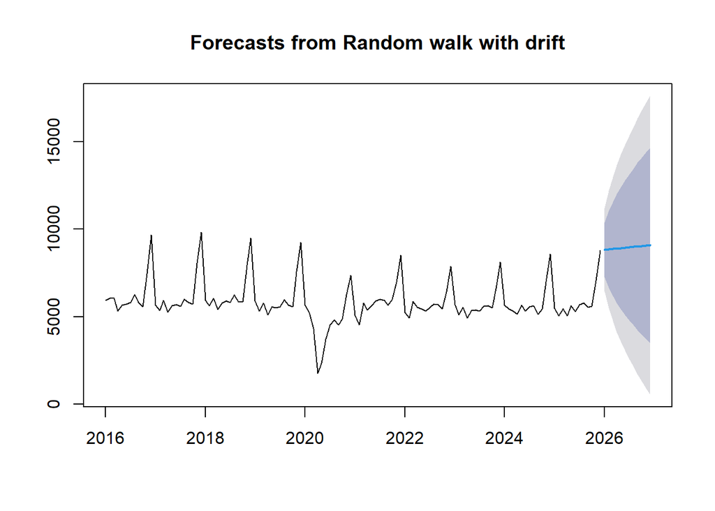

```r
plot(drift_forecast)
```

The random walk model produces the same forecasts as the naive method, using the most recent value of $8,799 million for each future month. When drift is added, the forecast gradually increases from approximately $8,823.1 million in January 2026 as the model incorporates the average change over time. However, neither model accounts for the recurring monthly seasonal pattern in the data. The widening prediction intervals also indicate that uncertainty increases as the forecast extends further into the future.

## Seasonal Naive Forecast

```r
snaive_forecast <- snaive(electronics_ts, h = 12)
snaive_forecast
```

```
##          Point Forecast    Lo 80    Hi 80    Lo 95     Hi 95
## Jan 2026           5473 4353.743 6592.257 3761.244  7184.756
## Feb 2026           5067 3947.743 6186.257 3355.244  6778.756
## Mar 2026           5437 4317.743 6556.257 3725.244  7148.756
## Apr 2026           5051 3931.743 6170.257 3339.244  6762.756
## May 2026           5631 4511.743 6750.257 3919.244  7342.756
## Jun 2026           5310 4190.743 6429.257 3598.244  7021.756
## Jul 2026           5685 4565.743 6804.257 3973.244  7396.756
## Aug 2026           5787 4667.743 6906.257 4075.244  7498.756
## Sep 2026           5546 4426.743 6665.257 3834.244  7257.756
## Oct 2026           5589 4469.743 6708.257 3877.244  7300.756
## Nov 2026           7047 5927.743 8166.257 5335.244  8758.756
## Dec 2026           8799 7679.743 9918.257 7087.244 10510.756
```

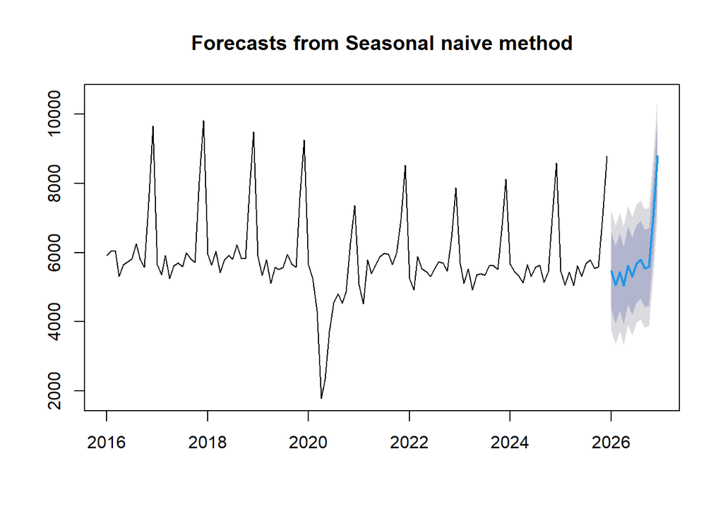

```r
plot(snaive_forecast)
```

The seasonal naive method forecasts each month using the value from the same month of the previous year. For example, January 2026 is forecasted at $5,473 million, which is the observed value from January 2025. Unlike the mean and naive methods, this model captures the recurring seasonal pattern in the data, including the higher electronics store sales near the end of the year. This makes the seasonal naive method more appropriate for a time series with noticeable monthly seasonality.

## Moving Average

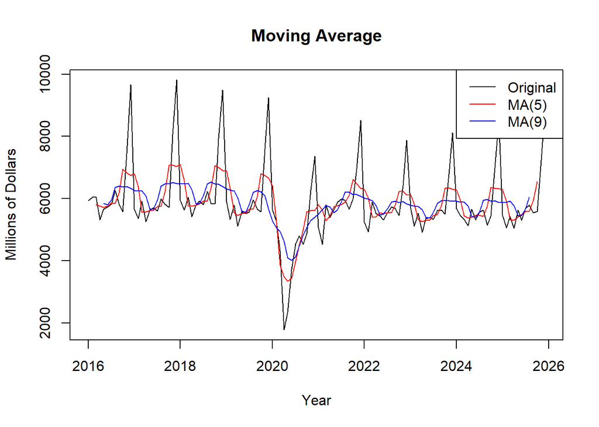

```r
MA5 <- ma(electronics_ts, order = 5)
MA9 <- ma(electronics_ts, order = 9)
plot(electronics_ts, main = "Moving Average", xlab = "Year", ylab = "Millions of Dollars")

lines(MA5, col = "red")
lines(MA9, col = "blue")
legend("topright", legend = c("Original", "MA(5)", "MA(9)"), col = c("black", "red", "blue"), lty = 1)
```

The moving average method smooths short-term fluctuations in the time series to make the underlying pattern easier to observe. The MA(5) line follows changes in electronics store sales more closely, while the MA(9) line is smoother because it averages over a larger number of periods. Both moving averages reduce the large monthly fluctuations in the original series, including the seasonal sales spikes. These moving averages are used here primarily to examine and smooth the historical pattern rather than to generate the 12-month forecasts used by the other models.

## ETS Forecast

```r
ets_model <- ets(electronics_ts)
ets_model
```

```
## ETS(A,N,A)
##
## Call:
## ets(y = electronics_ts)
##
##   Smoothing parameters:
##     alpha = 0.9999
##     gamma = 1e-04
##
##   Initial states:
##     l = 6245.165
##     s = 2904.03 1320.383 -289.3668 -315.1446 -57.9435 -330.1819
##            -480.8495 -597.9787 -987.4283 -266.9634 -624.407 -274.1485
##
##   sigma:  416.2745
##
##      AIC     AICc      BIC
## 2037.135 2041.751 2078.948
```

```r
ets_forecast <- forecast(ets_model, h = 12)
ets_forecast
```

```
##          Point Forecast    Lo 80     Hi 80    Lo 95     Hi 95
## Jan 2026       5620.827 5087.349  6154.304 4804.944  6436.710
## Feb 2026       5270.545 4516.132  6024.958 4116.770  6424.320
## Mar 2026       5627.981 4704.033  6551.928 4214.925  7041.037
## Apr 2026       4907.526 3840.652  5974.399 3275.883  6539.168
## May 2026       5296.970 4104.175  6489.765 3472.748  7121.193
## Jun 2026       5414.098 4107.461  6720.735 3415.769  7412.427
## Jul 2026       5564.790 4153.464  6976.116 3406.354  7723.227
## Aug 2026       5836.992 4328.224  7345.760 3529.530  8144.454
## Sep 2026       5579.807 3979.519  7180.095 3132.377  8027.236
## Oct 2026       5605.587 3918.737  7292.437 3025.773  8185.401
## Nov 2026       7215.324 5446.143  8984.505 4509.594  9921.053
## Dec 2026       8799.000 6951.136 10646.864 5972.936 11625.064
```

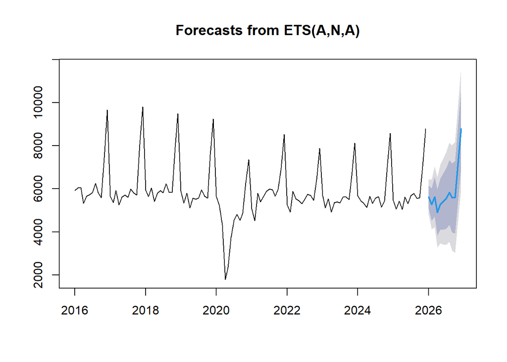

```r
plot(ets_forecast)
```

The ETS model automatically selected an ETS(A,N,A) specification, representing additive error, no trend, and additive seasonality. This indicates that the model identified a seasonal pattern in electronics store sales but did not identify a trend component that needed to be included in the forecast. Unlike the mean, naive, and random walk methods, the ETS forecasts change across the months of 2026 to account for seasonality. For example, the model forecasts approximately $5,620.8 million in January 2026 and $4,907.5 million in April 2026. The forecast plot shows that the model continues the recurring seasonal pattern observed in the historical data.

## Holt-Winters Forecast

```r
HW_model <- HoltWinters(electronics_ts)
HW_model
```

```
## Holt-Winters exponential smoothing with trend and additive seasonal component.
##
## Call:
## HoltWinters(x = electronics_ts)
##
## Smoothing parameters:
##  alpha: 0.8308524
##  beta : 0
##  gamma: 1
##
## Coefficients:
##            [,1]
## a   5922.381507
## b     -6.570221
## s1    10.333630
## s2  -595.798269
## s3  -321.355496
## s4  -908.018990
## s5  -578.965925
## s6  -571.436283
## s7  -262.678054
## s8   -87.388485
## s9  -300.397599
## s10 -297.113069
## s11 1118.785958
## s12 2876.618493
```

```r
HW_forecast <- forecast(HW_model, h = 12)
HW_forecast
```

```
##          Point Forecast    Lo 80     Hi 80    Lo 95     Hi 95
## Jan 2026       5926.145 5341.875  6510.415 5032.581  6819.709
## Feb 2026       5313.443 4553.820  6073.065 4151.701  6475.185
## Mar 2026       5581.315 4679.827  6482.803 4202.608  6960.022
## Apr 2026       4988.082 3964.199  6011.964 3422.189  6553.974
## May 2026       5310.564 4177.432  6443.697 3577.588  7043.541
## Jun 2026       5311.524 4078.786  6544.262 3426.213  7196.834
## Jul 2026       5613.712 4288.835  6938.589 3587.488  7639.936
## Aug 2026       5782.431 4371.420  7193.442 3624.476  7940.387
## Sep 2026       5562.852 4070.670  7055.034 3280.757  7844.947
## Oct 2026       5559.566 3990.407  7128.726 3159.744  7959.388
## Nov 2026       6968.895 5326.362  8611.428 4456.857  9480.933
## Dec 2026       8720.157 7007.391 10432.924 6100.707 11339.608
```

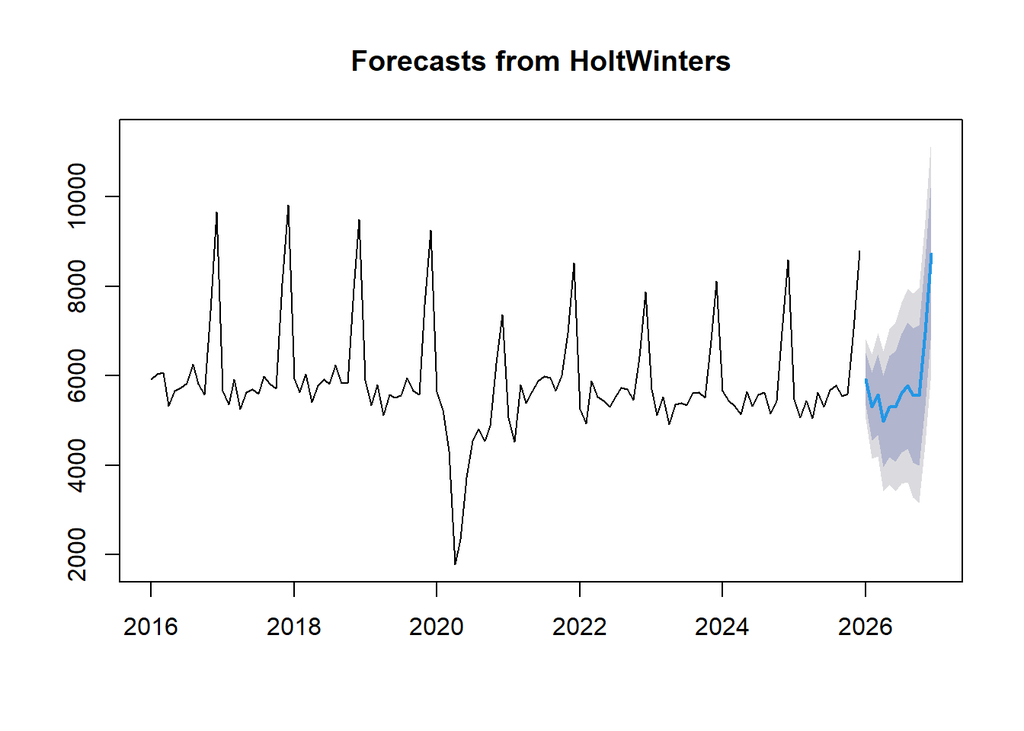

```r
plot(HW_forecast)
```

The Holt-Winters model uses level, trend, and an additive seasonal component to forecast electronics store sales. The fitted model produced smoothing parameters of alpha = 0.831, beta = 0, and gamma = 1. The model identifies a strong seasonal component, which is consistent with the recurring increases in electronics store sales near the end of each year. The estimated trend is relatively small, while the forecasts continue to show substantial monthly variation. For example, the model forecasts approximately $5,926.1 million in January 2026 and $4,988.1 million in April 2026.

## Simple Exponential Smoothing

```r
ses_forecast <- ses(electronics_ts, h = 12)
ses_forecast
```

```
##          Point Forecast    Lo 80     Hi 80    Lo 95    Hi 95
## Jan 2026       8015.372 6499.891  9530.853 5697.644 10333.10
## Feb 2026       8015.372 6205.625  9825.119 5247.603 10783.14
## Mar 2026       8015.372 5952.926 10077.818 4861.133 11169.61
## Apr 2026       8015.372 5727.975 10302.769 4517.101 11513.64
## May 2026       8015.372 5523.248 10507.497 4203.997 11826.75
## Jun 2026       8015.372 5334.107 10696.638 3914.730 12116.01
## Jul 2026       8015.372 5157.456 10873.288 3644.566 12386.18
## Aug 2026       8015.372 4991.106 11039.638 3390.156 12640.59
## Sep 2026       8015.372 4833.441 11197.303 3149.028 12881.72
## Oct 2026       8015.372 4683.228 11347.516 2919.297 13111.45
## Nov 2026       8015.372 4539.500 11491.244 2699.485 13331.26
## Dec 2026       8015.372 4401.484 11629.260 2488.407 13542.34
```

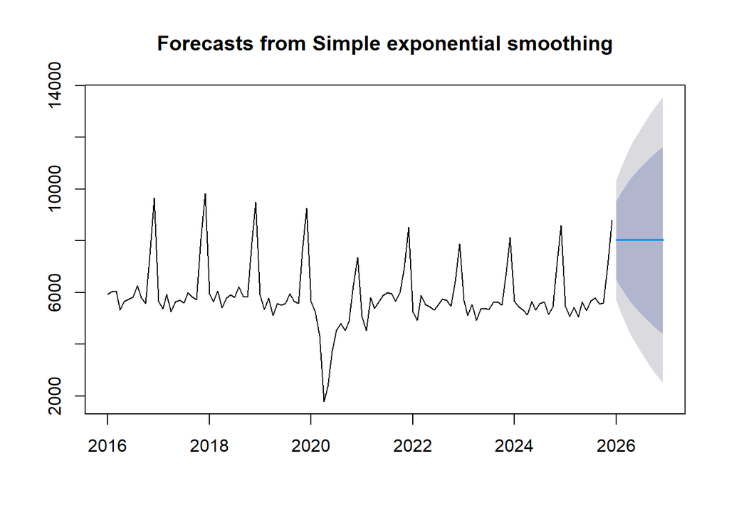

```r
plot(ses_forecast)
```

Simple exponential smoothing forecasts future values by estimating the current level of the time series while giving more weight to recent observations. The model forecasts approximately $8,015.4 million for each month of 2026. The forecast remains constant because simple exponential smoothing does not include a trend or seasonal component. This is a limitation for the electronics store sales data because the historical series shows a recurring seasonal pattern, particularly the higher sales near the end of each year.

## Model Accuracy Comparison

To compare the forecasting models, the data were divided into a training set and a test set. The models were trained using observations from 2016 through 2024 and used to forecast the 12 months of 2025. These forecasts were then compared with the actual 2025 sales values.

```r
train <- window(electronics_ts, end = c(2024, 12))
test <- window(electronics_ts, start = c(2025, 1))
length(train)
```

```
## [1] 108
```

```r
length(test)
```

```
## [1] 12
```

### Forecast the Test Period

```r
mean_test <- meanf(train, h = 12)
naive_test <- naive(train, h = 12)
drift_test <- rwf(train, h = 12, drift = TRUE)
snaive_test <- snaive(train, h = 12)
ets_test <- forecast(ets(train), h = 12)
HW_test <- forecast(HoltWinters(train), h = 12)
ses_test <- ses(train, h = 12)
```

### RMSE Comparison

```r
rmse_results <- data.frame(
  Model = c("Mean", "Naive", "Random Walk with Drift", "Seasonal Naive", "ETS", "Holt-Winters", "Simple Exponential Smoothing"),
  RMSE = c(
    accuracy(mean_test, test)["Test set", "RMSE"],
    accuracy(naive_test, test)["Test set", "RMSE"],
    accuracy(drift_test, test)["Test set", "RMSE"],
    accuracy(snaive_test, test)["Test set", "RMSE"],
    accuracy(ets_test, test)["Test set", "RMSE"],
    accuracy(HW_test, test)["Test set", "RMSE"],
    accuracy(ses_test, test)["Test set", "RMSE"]
  )
)
rmse_results$RMSE <- round(rmse_results$RMSE, 2)
rmse_results
```

```
##                          Model    RMSE
## 1                         Mean 1009.16
## 2                        Naive 2896.02
## 3       Random Walk with Drift 3029.02
## 4               Seasonal Naive  196.07
## 5                          ETS  261.66
## 6                 Holt-Winters  278.98
## 7 Simple Exponential Smoothing 2295.03
```

RMSE was used to compare the forecasting accuracy of the models using 2025 as the test period. A lower RMSE indicates better forecasting accuracy. The Seasonal Naive model produced the lowest RMSE of 196.07, followed by ETS with an RMSE of 261.66 and Holt-Winters with an RMSE of 278.98. Therefore, based on RMSE, the Seasonal Naive model was the most accurate model for this dataset. This result suggests that the recurring yearly seasonal pattern is particularly important when forecasting monthly electronics store sales.

## Comparison of Model Forecasts

The following chart compares the forecasts produced by the different forecasting models for 2026.

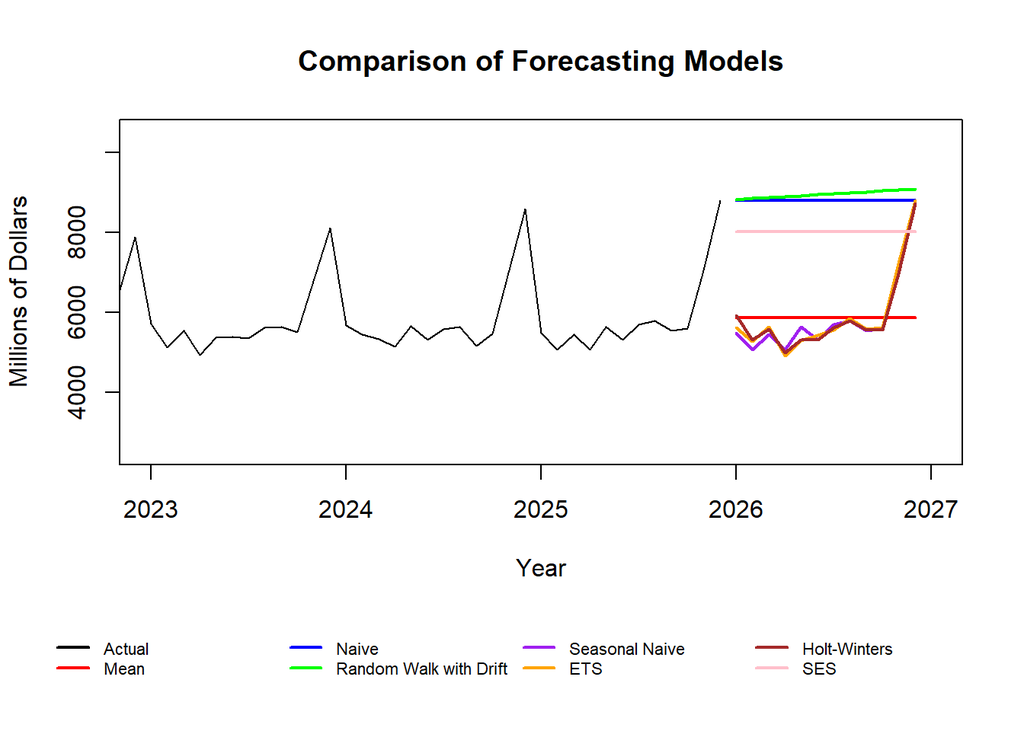

```r
layout(matrix(c(1, 2), nrow = 2),
       heights = c(4, 1))
par(mar = c(4, 4, 4, 2) + 0.1)

plot(electronics_ts, xlim = c(2023, 2027), ylim = c(2500, 10500), main = "Comparison of Forecasting Models", xlab = "Year", ylab = "Millions of Dollars")

lines(mean_forecast$mean, col = "red", lwd = 2)
lines(naive_forecast$mean, col = "blue", lwd = 2)
lines(drift_forecast$mean, col = "green", lwd = 2)
lines(snaive_forecast$mean, col = "purple", lwd = 2)
lines(ets_forecast$mean, col = "orange", lwd = 2)
lines(HW_forecast$mean, col = "brown", lwd = 2)
lines(ses_forecast$mean, col = "pink", lwd = 2)

par(mar = c(0, 0, 0, 0))

plot.new()

legend("center",
       legend = c("Actual",
                  "Mean",
                  "Naive",
                  "Random Walk with Drift",
                  "Seasonal Naive",
                  "ETS",
                  "Holt-Winters",
                  "SES"),
       col = c("black",
               "red",
               "blue",
               "green",
               "purple",
               "orange",
               "brown",
               "pink"),
       lty = 1,
       lwd = 2,
       ncol = 4,
       cex = 0.7,
       bty = "n")
```

```r
layout(1)
```

The combined forecast plot shows noticeable differences among the forecasting methods. The Mean model produces a constant forecast near the historical average, while the Naive, Random Walk with Drift, and Simple Exponential Smoothing models produce relatively high forecasts after the elevated December 2025 observation. In contrast, the Seasonal Naive, ETS, and Holt-Winters models reproduce the monthly variation seen in the historical data. These differences demonstrate the importance of accounting for seasonality when forecasting electronics store sales. The accuracy comparison further supports this observation, as the Seasonal Naive model produced the lowest RMSE among the models tested.